# Биостатистика. ДЗ 2

95-871

2025-04-20

# ДЗ №2

## Загрузка пакетов и данных

```r
library(dplyr)
library(tidyr)
library(broom)
library(ROCR)
library(mboost)
```

```r
library(powerSurvEpi)
library(ggplot2)
wbc <- read.csv("wisconsin_breast_cancer.csv")
glimpse(wbc)
```

```
## Rows: 569
## Columns: 33
## $ id                      <int> 842302, 842517, 84300903, 84348301, 84358402, …
## $ diagnosis               <chr> "M", "M", "M", "M", "M", "M", "M", "M", "M", "…
## $ radius_mean             <dbl> 17.990, 20.570, 19.690, 11.420, 20.290, 12.450…
## $ texture_mean            <dbl> 10.38, 17.77, 21.25, 20.38, 14.34, 15.70, 19.9…
## $ perimeter_mean          <dbl> 122.80, 132.90, 130.00, 77.58, 135.10, 82.57, …
## $ area_mean               <dbl> 1001.0, 1326.0, 1203.0, 386.1, 1297.0, 477.1, …
## $ smoothness_mean         <dbl> 0.11840, 0.08474, 0.10960, 0.14250, 0.10030, 0…
## $ compactness_mean        <dbl> 0.27760, 0.07864, 0.15990, 0.28390, 0.13280, 0…
## $ concavity_mean          <dbl> 0.30010, 0.08690, 0.19740, 0.24140, 0.19800, 0…
## $ concave.points_mean     <dbl> 0.14710, 0.07017, 0.12790, 0.10520, 0.10430, 0…
## $ symmetry_mean           <dbl> 0.2419, 0.1812, 0.2069, 0.2597, 0.1809, 0.2087…
## $ fractal_dimension_mean  <dbl> 0.07871, 0.05667, 0.05999, 0.09744, 0.05883, 0…
## $ radius_se               <dbl> 1.0950, 0.5435, 0.7456, 0.4956, 0.7572, 0.3345…
```

[output cut: 20 more lines]

```r
wbc$X <- NULL

# Преобразование diagnosis в бинарное представление
wbc$diagnosis <- ifelse(wbc$diagnosis == "M", 1, 0)

# Разделение данных на обучающую и тестовую выборки
set.seed(42)  # Для воспроизводимости результата
train_index <- sample(nrow(wbc), 0.8*nrow(wbc))
wbc_train <- wbc[train_index, ]
wbc_test <- wbc[-train_index, ]
```

## Задание 1

Создайте регрессионную модель (или несколько моделей), которая описывала бы связь:

- среднего радиуса опухоли и средней площади;
- среднего периметра;
- средней симметричности.

Постройте график (или графики, если моделей несколько), на котором отразите регрессионную прямую, и прокомментируйте свои находки.

Гипотезы:

- площадь зависит от радиуса квадратично (S = pi*R^2): применим полиномиальную регрессию 2-го порядка;
- периметр зависит от радиуса линейно (C = 2*pi*R): применим линейную регрессию;
- симметричность - нет предположений: применим различные модели.

```r
# Создание регрессионных моделей
# radius_mean ~ area_mean: полиномиальная регрессия порядка 2
model1 <- lm(radius_mean ~ poly(area_mean, 2), data = wbc_train)

# radius_mean ~ perimeter_mean: линейная регрессия
model2 <- lm(radius_mean ~ perimeter_mean, data = wbc_train)

# radius_mean ~ symmetry_mean: линейная регрессия
model3 <- lm(radius_mean ~ symmetry_mean, data = wbc_train)
# radius_mean ~ symmetry_mean: полиномиальная регрессия порядка 2
model4 <- lm(radius_mean ~ poly(symmetry_mean, 2), data = wbc_train)
# radius_mean ~ symmetry_mean: полиномиальная регрессия порядка 3
model5 <- lm(radius_mean ~ poly(symmetry_mean, 3), data = wbc_train)

# Расчет метрик MAE, MAPE, RMSE, R2 на тестовой выборке
models <- list(model1, model2, model3, model4, model5)
model_names <- c("area_mean_poly2", "perimeter_mean_lin", "symmetry_mean_lin",
                 "symmetry_mean_poly2", "symmetry_mean_poly3")
metrics <- data.frame()

for (i in seq_along(models)) {
  model <- models[[i]]
  predictions <- predict(model, newdata = wbc_test)
  actual <- wbc_test$radius_mean

  mae <- mean(abs(actual - predictions))
  mape <- mean(abs((actual - predictions) / actual)) * 100
  rmse <- sqrt(mean((actual - predictions)^2))
  r2 <- 1 - (sum((actual - predictions)^2) / sum((actual - mean(actual))^2))

  metrics <- rbind(metrics, data.frame(Model = model_names[i], MAE = mae, MAPE = mape, RMSE = rmse, R2 = r2))
}

# Отображение результатов и таблицы метрик
for (i in seq_along(models)) {
  cat("\nSummary для модели:", model_names[i], "\n")
  print(summary(models[[i]]))
}
```

```
##
## Summary для модели: area_mean_poly2
##
## Call:
## lm(formula = radius_mean ~ poly(area_mean, 2), data = wbc_train)
##
## Residuals:
##      Min       1Q   Median       3Q      Max
## -1.02701 -0.08565  0.05453  0.12287  1.17876
##
## Coefficients:
##                      Estimate Std. Error t value Pr(>|t|)
## (Intercept)          14.14459    0.01034 1368.11   <2e-16 ***
## poly(area_mean, 2)1  75.09871    0.22053  340.53   <2e-16 ***
## poly(area_mean, 2)2 -10.36954    0.22053  -47.02   <2e-16 ***
## ---
## Signif. codes:  0 '***' 0.001 '**' 0.01 '*' 0.05 '.' 0.1 ' ' 1
##
## Residual standard error: 0.2205 on 452 degrees of freedom
## Multiple R-squared:  0.9962, Adjusted R-squared:  0.9962
## F-statistic: 5.909e+04 on 2 and 452 DF,  p-value: < 2.2e-16
##
##
## Summary для модели: perimeter_mean_lin
##
## Call:
## lm(formula = radius_mean ~ perimeter_mean, data = wbc_train)
##
## Residuals:
##      Min       1Q   Median       3Q      Max
## -1.42329 -0.10142  0.02993  0.14519  0.55328
##
## Coefficients:
##                 Estimate Std. Error t value Pr(>|t|)
## (Intercept)    0.8325437  0.0421870   19.73   <2e-16 ***
## perimeter_mean 0.1445424  0.0004426  326.60   <2e-16 ***
## ---
## Signif. codes:  0 '***' 0.001 '**' 0.01 '*' 0.05 '.' 0.1 ' ' 1
##
## Residual standard error: 0.2321 on 453 degrees of freedom
```

[output cut: 53 more lines]

```
##     Min      1Q  Median      3Q     Max
## -7.3751 -2.4315 -0.5869  1.6047 14.2094
##
## Coefficients:
##                         Estimate Std. Error t value Pr(>|t|)
## (Intercept)              14.1446     0.1656  85.389  < 2e-16 ***
## poly(symmetry_mean, 3)1  11.5072     3.5334   3.257  0.00121 **
## poly(symmetry_mean, 3)2   0.7035     3.5334   0.199  0.84227
## poly(symmetry_mean, 3)3   2.3733     3.5334   0.672  0.50213
## ---
## Signif. codes:  0 '***' 0.001 '**' 0.01 '*' 0.05 '.' 0.1 ' ' 1
##
## Residual standard error: 3.533 on 451 degrees of freedom
## Multiple R-squared:  0.02401,    Adjusted R-squared:  0.01752
## F-statistic: 3.699 on 3 and 451 DF,  p-value: 0.01186
```

```r
print(metrics)
```

```
##                 Model       MAE      MAPE      RMSE         R2
## 1     area_mean_poly2 0.1534198  1.155829 0.1887714 0.99683603
## 2  perimeter_mean_lin 0.1709484  1.214442 0.2262977 0.99545305
## 3   symmetry_mean_lin 2.5782256 18.890217 3.3294776 0.01573413
## 4 symmetry_mean_poly2 2.5813248 18.912659 3.3355530 0.01213881
## 5 symmetry_mean_poly3 2.5787446 18.871708 3.3331303 0.01357330
```

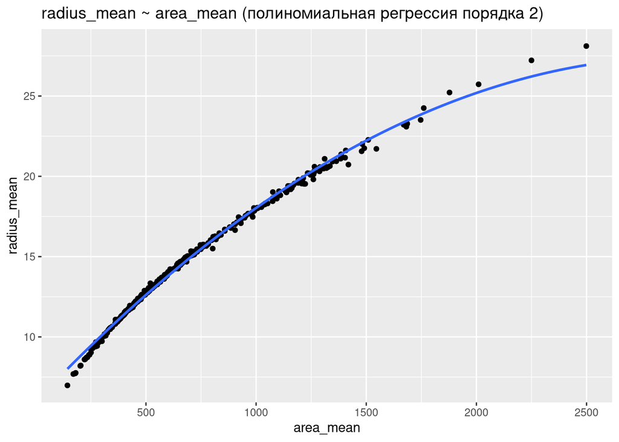

```r
# Построение графиков с регрессионными кривыми
# radius_mean ~ area_mean
ggplot(wbc_train, aes(x = area_mean, y = radius_mean)) +
  geom_point() +
  geom_smooth(method = "lm", formula = y ~ poly(x, 2), se = FALSE) +
  labs(title = "radius_mean ~ area_mean (полиномиальная регрессия порядка 2)")
```

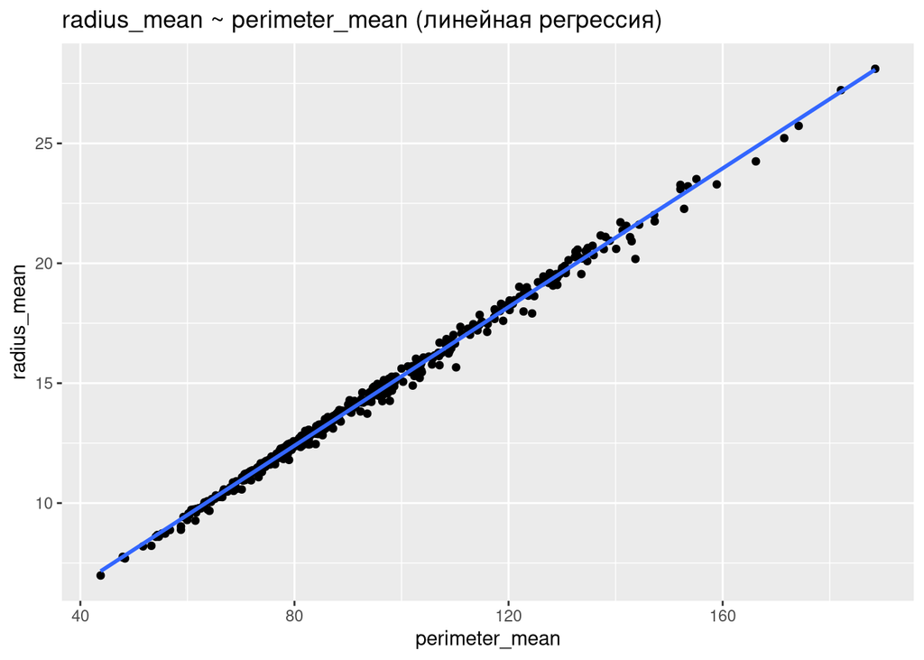

```r
# radius_mean ~ perimeter_mean
ggplot(wbc_train, aes(x = perimeter_mean, y = radius_mean)) +
  geom_point() +
  geom_smooth(method = "lm", se = FALSE) +
  labs(title = "radius_mean ~ perimeter_mean (линейная регрессия)")
```

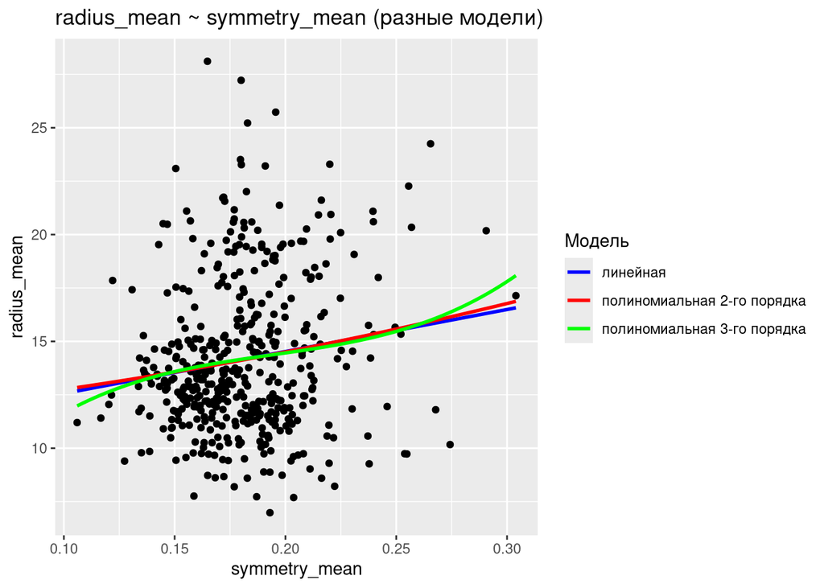

```r
# radius_mean ~ symmetry_mean для разных моделей
ggplot(wbc_train, aes(x = symmetry_mean, y = radius_mean)) +
  geom_point() +
  geom_smooth(method = "lm", se = FALSE, aes(color = "линейная")) +
  geom_smooth(method = "lm", formula = y ~ poly(x, 2), se = FALSE, aes(color = "полиномиальная 2-го порядка")) +
  geom_smooth(method = "lm", formula = y ~ poly(x, 3), se = FALSE, aes(color = "полиномиальная 3-го порядка")) +
  labs(title = "radius_mean ~ symmetry_mean (разные модели)") +
  scale_color_manual(name = "Модель", values = c("линейная" = "blue", "полиномиальная 2-го порядка" = "red", "полиномиальная 3-го порядка" = "green"))
```

Выводы:

Исходя из крайне высоких значений коэффициента детерминации для моделей radius_mean ~ area_mean и radius_mean ~ perimeter_mean (0.997 и 0.995 соотв.) и результатов визуализации, гипотезы о квадратичной зависимости площади от радиуса и линейной зависимости периметра от радиуса можно считать подтверждёнными.

Что касается средней симметричности - ни одна из моделей (линейная, полиномиальная 2-го порядка, полиномиальная 3-го порядка) не показала хоть сколь-нибудь приемлемого результата. Из визуализации очевидно, что используя только среднюю симметричность невозможно предсказать радиус - требуются дополнительные предикторы.

## Задание 2

Пусть колонка с диагнозом принимает следующие значения: злокачественная опухоль (M) — 1, а доброкачественная (B) — 0. Постройте модель (или несколько моделей), которая прогнозировала бы вероятность возникновения злокачественной опухоли:

- от среднего радиуса;
- средней площади;
- средней текстуры.

Постройте графики. Создайте модель, которая бы прогнозировала вероятность возникновения злокачественной опухоли от всех трех перечисленных факторов.

Построим модели для прогнозирования вероятности возникновения злокачественной опухоли от перечисленных трёх факторов по отдельности

```r
# Построение моделей логистической регрессии
model1 <- glm(diagnosis ~ radius_mean, data = wbc_train, family = "binomial")
model2 <- glm(diagnosis ~ area_mean, data = wbc_train, family = "binomial")
model3 <- glm(diagnosis ~ texture_mean, data = wbc_train, family = "binomial")

# Рассчет метрик F1 и AUC-ROC
models <- list(model1, model2, model3)
model_names <- c("radius_mean", "area_mean", "texture_mean")
metrics <- data.frame()

for (i in seq_along(models)) {
  model <- models[[i]]
  predictions <- predict(model, newdata = wbc_test, type = "response")
  pred_class <- ifelse(predictions > 0.5, 1, 0)

  # F1
  precision <- sum(wbc_test$diagnosis == 1 & pred_class == 1) / sum(pred_class == 1)
  recall <- sum(wbc_test$diagnosis == 1 & pred_class == 1) / sum(wbc_test$diagnosis == 1)
  f1 <- 2 * precision * recall / (precision + recall)

  # AUC-ROC
  pred <- prediction(predictions, wbc_test$diagnosis)
  perf <- performance(pred, measure = "auc")
  auc <- perf@y.values[[1]]

  metrics <- rbind(metrics, data.frame(Model = model_names[i], F1 = f1, AUC_ROC = auc))
}

# Отображение результатов и таблицы метрик
for (i in seq_along(models)) {
  cat("\nSummary для модели:", model_names[i], "\n")
  print(summary(models[[i]]))
}
```

```
##
## Summary для модели: radius_mean
##
## Call:
## glm(formula = diagnosis ~ radius_mean, family = "binomial", data = wbc_train)
##
## Coefficients:
##             Estimate Std. Error z value Pr(>|z|)
## (Intercept) -15.7105     1.5386 -10.211   <2e-16 ***
## radius_mean   1.0694     0.1083   9.874   <2e-16 ***
## ---
## Signif. codes:  0 '***' 0.001 '**' 0.01 '*' 0.05 '.' 0.1 ' ' 1
##
## (Dispersion parameter for binomial family taken to be 1)
##
##     Null deviance: 603.41  on 454  degrees of freedom
## Residual deviance: 255.51  on 453  degrees of freedom
## AIC: 259.51
##
## Number of Fisher Scoring iterations: 6
##
##
## Summary для модели: area_mean
##
## Call:
## glm(formula = diagnosis ~ area_mean, family = "binomial", data = wbc_train)
##
## Coefficients:
##              Estimate Std. Error z value Pr(>|z|)
## (Intercept) -8.232666   0.796228 -10.340   <2e-16 ***
## area_mean    0.012248   0.001274   9.616   <2e-16 ***
## ---
## Signif. codes:  0 '***' 0.001 '**' 0.01 '*' 0.05 '.' 0.1 ' ' 1
##
## (Dispersion parameter for binomial family taken to be 1)
##
##     Null deviance: 603.41  on 454  degrees of freedom
## Residual deviance: 251.58  on 453  degrees of freedom
## AIC: 255.58
##
```

[output cut: 8 more lines]

```
##
## Coefficients:
##              Estimate Std. Error z value Pr(>|z|)
## (Intercept)  -4.60059    0.54934  -8.375  < 2e-16 ***
## texture_mean  0.20751    0.02705   7.671 1.71e-14 ***
## ---
## Signif. codes:  0 '***' 0.001 '**' 0.01 '*' 0.05 '.' 0.1 ' ' 1
##
## (Dispersion parameter for binomial family taken to be 1)
##
##     Null deviance: 603.41  on 454  degrees of freedom
## Residual deviance: 529.41  on 453  degrees of freedom
## AIC: 533.41
##
## Number of Fisher Scoring iterations: 3
```

```r
print(metrics)
```

```
##          Model        F1   AUC_ROC
## 1  radius_mean 0.8157895 0.9195946
## 2    area_mean 0.7837838 0.9192568
## 3 texture_mean 0.3636364 0.8464527
```

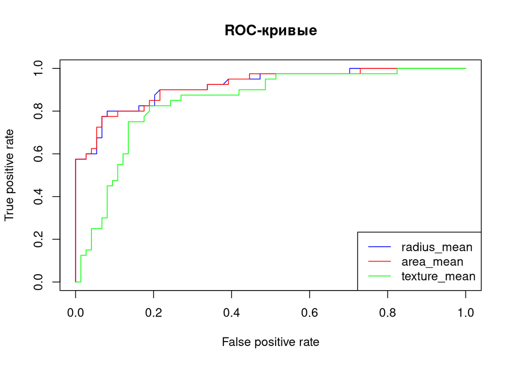

```r
# Построение ROC-кривых
pred1 <- prediction(predict(model1, newdata = wbc_test, type = "response"), wbc_test$diagnosis)
perf1 <- performance(pred1, measure = "tpr", x.measure = "fpr")

pred2 <- prediction(predict(model2, newdata = wbc_test, type = "response"), wbc_test$diagnosis)
perf2 <- performance(pred2, measure = "tpr", x.measure = "fpr")

pred3 <- prediction(predict(model3, newdata = wbc_test, type = "response"), wbc_test$diagnosis)
perf3 <- performance(pred3, measure = "tpr", x.measure = "fpr")

plot(perf1, col = "blue", main = "ROC-кривые")
plot(perf2, col = "red", add = TRUE)
plot(perf3, col = "green", add = TRUE)
legend("bottomright", legend = c("radius_mean", "area_mean", "texture_mean"),
       col = c("blue", "red", "green"), lty = 1)
```

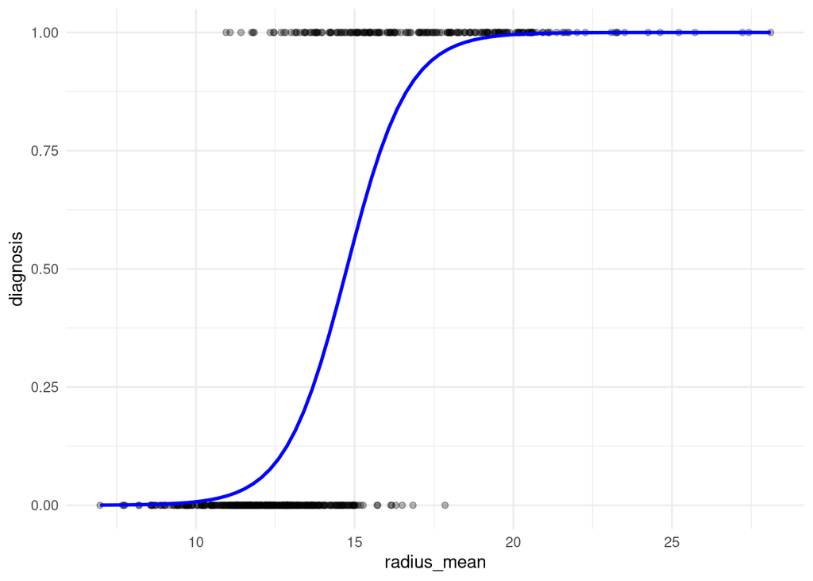

```r
#
ggplot(wbc, aes(x = radius_mean, y = diagnosis)) +
  geom_point(alpha = 0.3) +
  geom_smooth(method = "glm", method.args = list(family = "binomial"), se = FALSE, color = "blue") +
  theme_minimal()
```

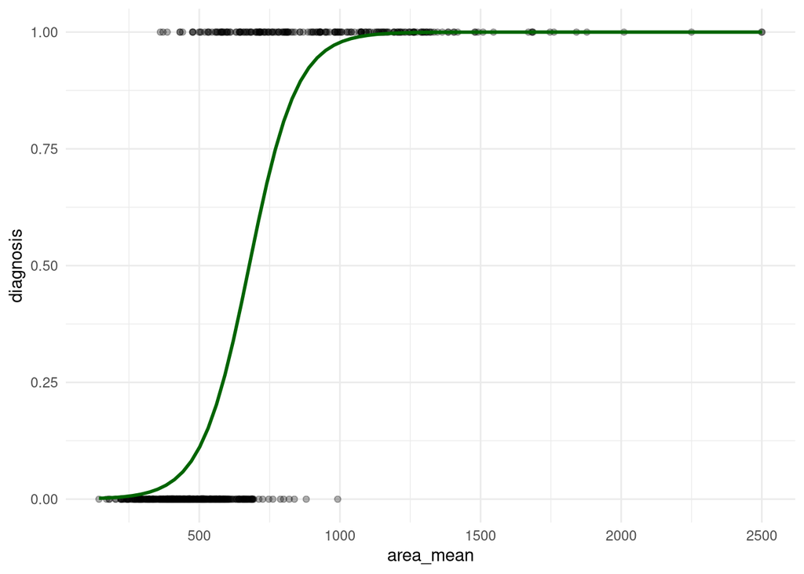

```r
ggplot(wbc, aes(x = area_mean, y = diagnosis)) +
  geom_point(alpha = 0.3) +
  geom_smooth(method = "glm", method.args = list(family = "binomial"), se = FALSE, color = "darkgreen") +
  theme_minimal()
```

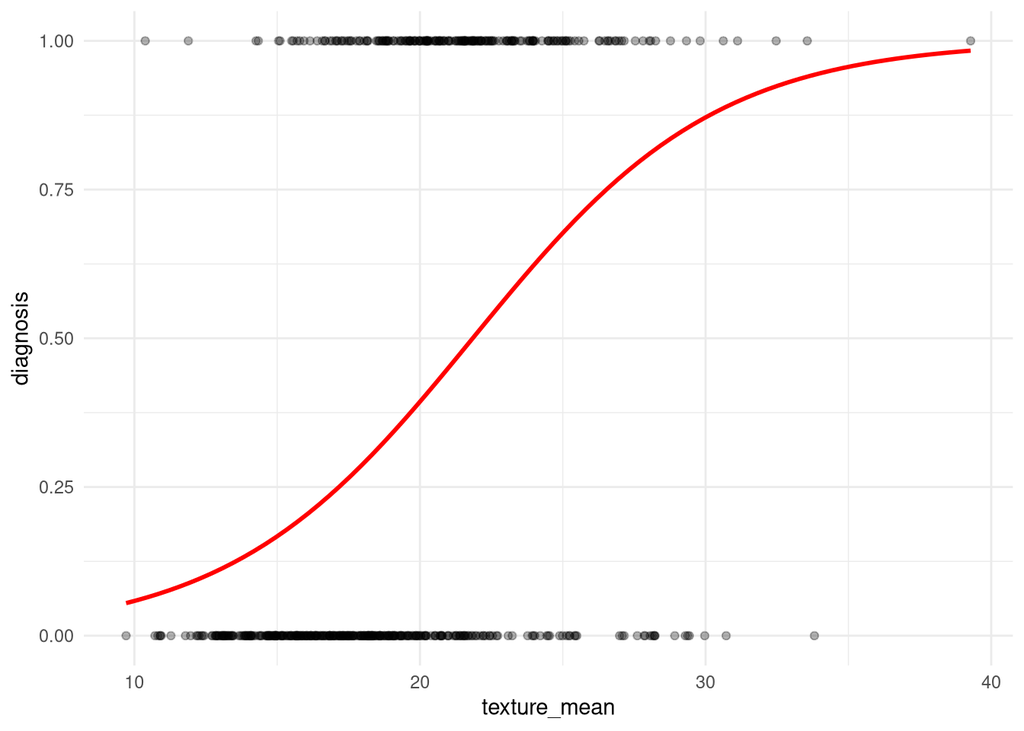

```r
ggplot(wbc, aes(x = texture_mean, y = diagnosis)) +
  geom_point(alpha = 0.3) +
  geom_smooth(method = "glm", method.args = list(family = "binomial"), se = FALSE, color = "red") +
  theme_minimal()
```

Выводы:

Все три фактора (средний радиус, средняя площадь, средняя текстура) по отдельности статистически значимо влияют на вероятность возникловения злокачественной опухоли. Лучшая модель - radius_mean демонстрирует очень хорошие результаты: F1 = 0.82, ROC-AUC = 0.92. Худшая - texture_mean: F1 = 0.36, ROC-AUC = 0.85. Значение метрики F1 существенно хуже.

Построим модоль для прогнозирования вероятности возникновения злокачественной опухоли от всех трех перечисленных факторов. В этом случае возникнет мультиколлинеарность т.к. area_mean и radius_mean сильно коррелируют. Будем использовать модель LogitBoost - она более устойчива к мультиколлинеарности по сравнению с традиционными линейными моделями, такими как логистическая регрессия. Тем не менее, возможна нестабильность важности признаков.

```r
# Преобразование diagnosis в фактор (требование glmboost из пакета mboost)
wbc$diagnosis <- factor(wbc$diagnosis, levels = c(0, 1))
wbc_train$diagnosis <- factor(wbc_train$diagnosis, levels = c(0, 1))
wbc_test$diagnosis <- factor(wbc_test$diagnosis, levels = c(0, 1))

# Построение модели logitboost
model <- glmboost(diagnosis ~ radius_mean + area_mean + texture_mean, data = wbc_train, family = Binomial())

# Summary модели
summary(model)
```

```
##
##   Generalized Linear Models Fitted via Gradient Boosting
##
## Call:
## glmboost.formula(formula = diagnosis ~ radius_mean + area_mean +     texture_mean, data = wbc_train, family = Binomial())
##
##
##   Negative Binomial Likelihood (logit link)
##
## Loss function: {
##      f <- pmin(abs(f), 36) * sign(f)
##      p <- exp(f)/(exp(f) + exp(-f))
##      y <- (y + 1)/2
##      -y * log(p) - (1 - y) * log(1 - p)
##  }
##
##
## Number of boosting iterations: mstop = 100
## Step size:  0.1
## Offset:  -0.2489762
##
## Coefficients:
```

```
##
## NOTE: Coefficients from a Binomial model are half the size of coefficients
##  from a model fitted via glm(... , family = 'binomial').
## See Warning section in ?coef.mboost
```

```
##   (Intercept)   radius_mean     area_mean  texture_mean
## -6.7849907520  0.3844046392  0.0001930125  0.0627285329
## attr(,"offset")
## [1] -0.2489762
##
## Selection frequencies:
##  radius_mean texture_mean    area_mean
##         0.66         0.22         0.12
```

```r
# Рассчет метрик F1 и AUC-ROC
predictions <- predict(model, newdata = wbc_test, type = "response")
pred_class <- ifelse(predictions > 0.5, 1, 0)

# F1
precision <- sum(wbc_test$diagnosis == 1 & pred_class == 1) / sum(pred_class == 1)
recall <- sum(wbc_test$diagnosis == 1 & pred_class == 1) / sum(wbc_test$diagnosis == 1)
f1 <- 2 * precision * recall / (precision + recall)

# AUC-ROC
pred <- prediction(predictions, wbc_test$diagnosis)
perf <- performance(pred, measure = "auc")
auc <- perf@y.values[[1]]

# Таблица с метриками
metrics <- data.frame(Model = "logitboost", F1 = f1, AUC_ROC = auc)
print(metrics)
```

```
##        Model        F1   AUC_ROC
## 1 logitboost 0.8157895 0.9425676
```

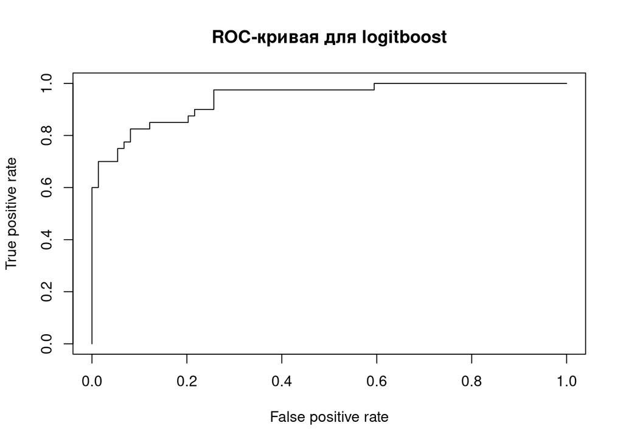

```r
# Построение ROC-кривой
perf <- performance(pred, measure = "tpr", x.measure = "fpr")
plot(perf, main = "ROC-кривая для logitboost")
```

Выводы:

Модель LogitBoost, использующая все три признака (средний радиус, средняя площадь, средняя текстура) показала такой же результат по метрике F1 = 0.82 и несколько лучший результат по метрике AUC-ROC = 0.94.

## Задание 3

Рассчитайте выборку для гипотезы equality для следующего исследования. Мы хотим сравнить новую терапию инфекции, присоединяющейся в больничных условиях у пациентов с ожогами, с золотым стандартом, основываясь на данных, анализируемых с помощью регрессии Кокса. Пусть отношение рисков «золотой стандарт / новая терапия», hazard ratio, HR = 2. Мы предполагаем, что 80% пациентов (d = 0,8) могут столкнуться с этим заболеванием. Соотношения групп терапии равны (p1 = p2 = 0,5).

n=n_1+n_2

```r
# Заданные параметры
HR <- 2
d <- 0.8
p1 <- 0.5
p2 <- 0.5
alpha <- 0.05

# Функция для расчета размера выборки
cox_sample_size_original <- function(HR, d, p1, p2, alpha = 0.05) {
  # Квантили нормального распределения
  z_alpha <- qnorm(1 - alpha / 2)

    # Расчет размера выборки в каждой группе
  n <- (z_alpha/2 + z_alpha)^2 * (log(HR)^2 * p1 * p2 * d)
  n <- ceiling(n) # Округление до ближайшего целого числа в большую сторону

  # Общий размер выборки
  total_n <- n * 2

  return(list(n_per_group = n, total_n = total_n))
}

result <- cox_sample_size_original(HR, d, p1, p2, alpha = alpha)

# Вывод результатов
print(paste("Размер выборки в каждой группе:", result$n_per_group))
```

```
## [1] "Размер выборки в каждой группе: 1"
```

```r
print(paste("Общий размер выборки:", result$total_n))
```

```
## [1] "Общий размер выборки: 2"
```

Возможно, в формуле ошибка и пропущен знак деления:

```r
# Функция для расчета размера выборки
cox_sample_size_corrected <- function(HR, d, p1, p2, alpha = 0.05) {
  # Квантили нормального распределения
  z_alpha <- qnorm(1 - alpha / 2)

    # Расчет размера выборки в каждой группе
  n <- (z_alpha/2 + z_alpha)^2 / (log(HR)^2 * p1 * p2 * d)
  n <- ceiling(n) # Округление до ближайшего целого числа в большую сторону

  # Общий размер выборки
  total_n <- n * 2

  return(list(n_per_group = n, total_n = total_n))
}

result <- cox_sample_size_corrected(HR, d, p1, p2, alpha = alpha)

# Вывод результатов
print(paste("Размер выборки в каждой группе:", result$n_per_group))
```

```
## [1] "Размер выборки в каждой группе: 90"
```

```r
print(paste("Общий размер выборки:", result$total_n))
```

```
## [1] "Общий размер выборки: 180"
```

Сравним результат, используя формулу, учитывающую мощность (1−β). Примем мощность = 0.8.

```r
# Функция для расчета размера выборки
cox_sample_size_power <- function(HR, d, p1, p2, alpha = 0.05, power = 0.8) {
  # Квантили нормального распределения
  z_alpha <- qnorm(1 - alpha / 2)
  z_beta <- qnorm(power)

  # Расчет размера выборки в каждой группе
  n <- (z_alpha + z_beta)^2 / (log(HR)^2 * p1 * p2 * d)
  n <- ceiling(n) # Округление до ближайшего целого числа в большую сторону

  # Общий размер выборки
  total_n <- n * 2

  return(list(n_per_group = n, total_n = total_n))
}

power <- 0.8

result <- cox_sample_size_power(HR, d, p1, p2, alpha = alpha, power = power)

# Вывод результатов
print(paste("Размер выборки в каждой группе:", result$n_per_group))
```

```
## [1] "Размер выборки в каждой группе: 82"
```

```r
print(paste("Общий размер выборки:", result$total_n))
```

```
## [1] "Общий размер выборки: 164"
```

Также рассчитаем результат, используя функцию ssizeCT.default из пакета powerSurvEpi:

```r
# Используем функцию ssizeCT.default из пакета powerSurvEpi
n <- ssizeCT.default(
  power = power,
  k = p1/p2,
  pC = d,
  pE = d/HR,
  RR = HR,
  alpha = alpha
)

# Вывод результатов
print(paste("Размер выборки в каждой группе:", ceiling(n[['nE']])))
```

```
## [1] "Размер выборки в каждой группе: 59"
```

```r
print(paste("Общий размер выборки:", ceiling(n[['nE']] + n[['nC']])))
```

```
## [1] "Общий размер выборки: 118"
```